### **Visualize global displacement by floods**

For this section, we are using subset data of countries and respective number of people displaced. In order to get a broad understanding of displacement over time, the graphs have been generated for every 10 years i.e. the number of people displaced has been mapped for the years 1985, 1995, 2005 amd 2015.

#### Data Cleaning

There were incorrect entries in country names as well as N/As in the number of people displaced. Country names were corrected e.g. removed space from front / back of country names. Only complete cases were taken into the analysis; so for entries with N/A, the entire row was omitted from analysis.

#### Data subset for each year

In order to make a plot for a year of interest, separate csv file for that year was generated using Python (‘Flood file.py’ attached separately). Output from Python file is a csv file for a year, which was saved separately as “country_flood_severity_displaced_year**.csv" to the working directory.

#### Visualizing areas with least to most Displaced

In order to find if there are any changes in the number of people displaced over time, and also to check global areas with most dosplaced, we have done data visualization of the global areas with least to most displaced.

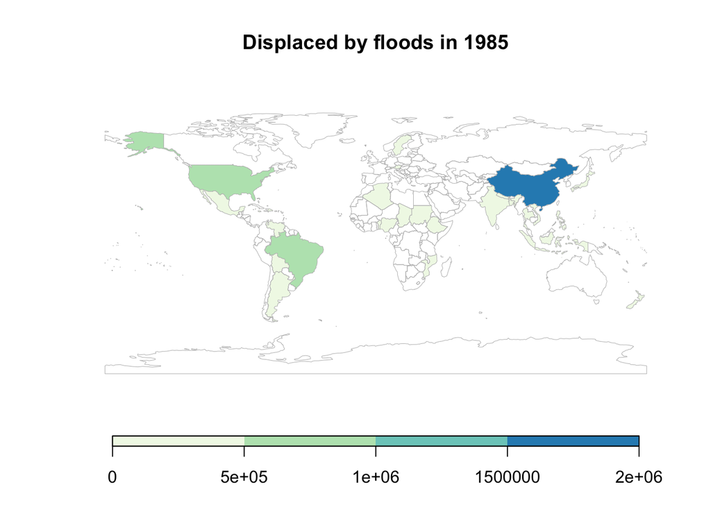

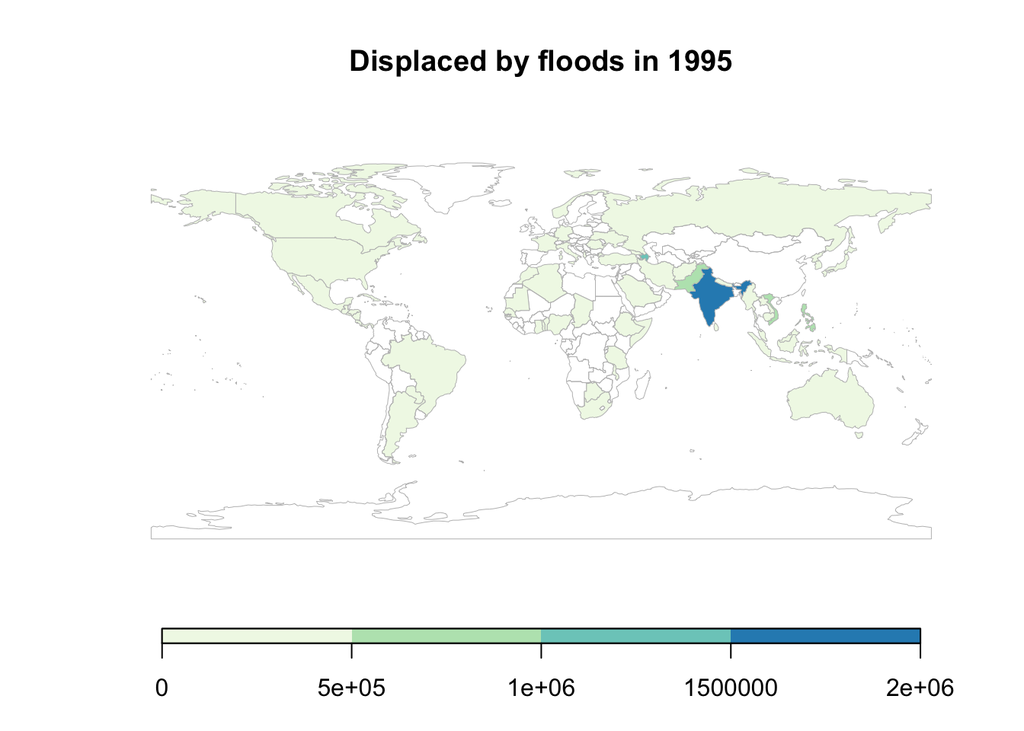

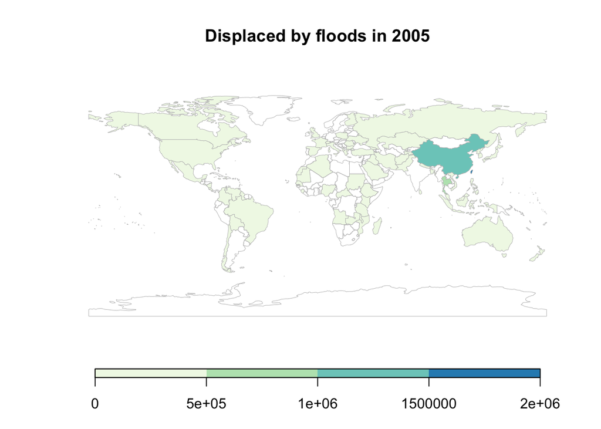

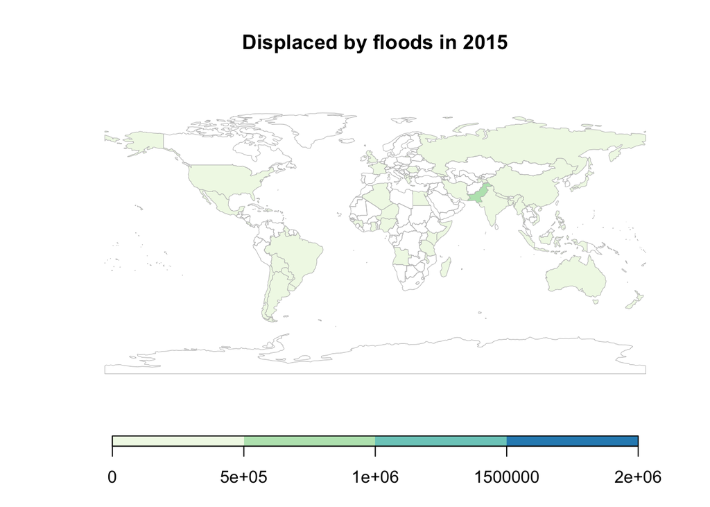